# Simple Linear Regression

INSOFE

14th December, 2019

## Simple Linear Regression Model

### Clear environment variables

```r
rm(list=ls(all=TRUE))
```

## Agenda

- Problem Statement
- Get the data
- Understand the data
- Explore the data
- Clean and Process the Data
- Model the data
- Evaluation and Communication

## Problem Statement

- We have provided a dataset with some details about cars. You are expected to build a linear regression model for the age and the price columns.

### Define the independent and dependent variables

- In Linear Regression, the dependent variable is continuous variable.
- For Simple Linear Regression we need one dependent and one independent variable
- For this example, we will consider the Price as dependent variable and the Age of the car as the independent variable.

### Reading & understanding the data

- Set working Directory and read the data from csv file

```r
# setwd("")
cars_data = read.csv(file="Toyota_SimpleReg.csv", header=T)   # Read the data from Toyota_SimpleReg.csv file
```

# EDA - Exploratory Data Analysis

- Look at the number of rows and columns
- Column names
- Look at the structure of the dataset using the function `str()`
- Look at the summary of the dataset using the `summary()`
- Checking for ‘NA’ values
- Perform Exploratory Data Analysis:

```r
nrow(cars_data)         # Number of rows in the dataset
```

```
## [1] 1436
```

```r
ncol(cars_data)         # Number of columns in the dataset
```

```
## [1] 4
```

```r
colnames(cars_data)     # Display the column names
```

```
## [1] "Id"        "Model"     "Price"     "Age_06_15"
```

```r
str(cars_data)          # Structure of the dataset
```

```
## 'data.frame':    1436 obs. of  4 variables:
##  $ Id       : int  1 2 3 4 5 6 7 8 9 10 ...
##  $ Model    : Factor w/ 372 levels "\xa0TOYOTA Corolla 1.3 16V HATCHB G6 2/3-Doors",..: 332 332 67 332 331 331 64 326 62 59 ...
##  $ Price    : int  13500 13750 13950 14950 13750 12950 16900 18600 21500 12950 ...
##  $ Age_06_15: int  57 57 58 60 64 66 61 64 61 57 ...
```

```r
summary(cars_data)      # Summary of the dataset
```

```
##        Id
##  Min.   :   1.0
##  1st Qu.: 361.8
##  Median : 721.5
##  Mean   : 721.6
##  3rd Qu.:1081.2
##  Max.   :1442.0
##
##                                                  Model
##  TOYOTA Corolla 1.6 16V HATCHB LINEA TERRA 2/3-Doors: 107
##  TOYOTA Corolla 1.3 16V HATCHB LINEA TERRA 2/3-Doors:  83
##  TOYOTA Corolla 1.6 16V LIFTB LINEA LUNA 4/5-Doors  :  79
##  TOYOTA Corolla 1.6 16V LIFTB LINEA TERRA 4/5-Doors :  70
##  TOYOTA Corolla 1.6 16V SEDAN LINEA TERRA 4/5-Doors :  43
##  TOYOTA Corolla 1.4 16V VVT I HATCHB TERRA 2/3-Doors:  42
##  (Other)                                            :1012
##      Price         Age_06_15
##  Min.   : 4350   Min.   : 35.00
##  1st Qu.: 8450   1st Qu.: 78.00
##  Median : 9900   Median : 95.00
##  Mean   :10731   Mean   : 89.95
##  3rd Qu.:11950   3rd Qu.:104.00
##  Max.   :32500   Max.   :114.00
##
```

## Look for Missing Values

```r
sum(is.na(cars_data))
```

```
## [1] 0
```

## Data Pre-Processing

```r
## Drop the Id, Model attributes:

drop_cols <- c("Id","Model")
cars_data[ ,drop_cols] <- NULL
str(cars_data)
```

```
## 'data.frame':    1436 obs. of  2 variables:
##  $ Price    : int  13500 13750 13950 14950 13750 12950 16900 18600 21500 12950 ...
##  $ Age_06_15: int  57 57 58 60 64 66 61 64 61 57 ...
```

### Rename Age Column

```r
colnames(cars_data)[2] <- 'Age'
str(cars_data)
```

```
## 'data.frame':    1436 obs. of  2 variables:
##  $ Price: int  13500 13750 13950 14950 13750 12950 16900 18600 21500 12950 ...
##  $ Age  : int  57 57 58 60 64 66 61 64 61 57 ...
```

## Scatter Plot

- Plot the Dependent and Independent variables
- The type of plot used to see the relationship between two continuous variables is called as *Scatter Plot*

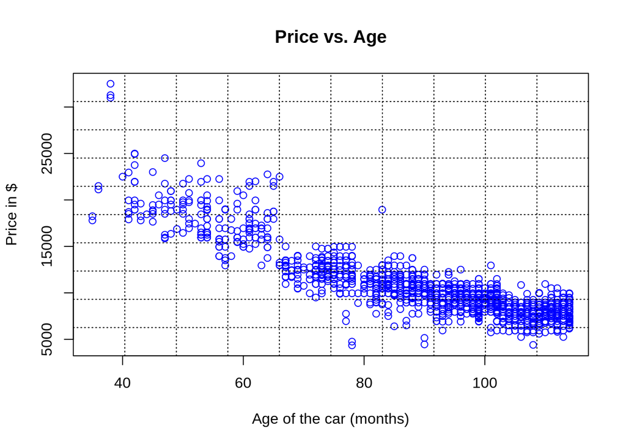

```r
# Plot the dependent and independent variables

plot(cars_data$Age,cars_data$Price,
      main = "Price vs. Age",
     xlab = "Age of the car (months)",
     ylab = "Price in $",
     col = "blue")
grid(10,10,lwd = 1,col='Black')
```

- What do you infer from the plot?

## Covariance between the attributes

```r
cov(cars_data)      # Covariance between independent and dependent variable
```

```
##             Price         Age
## Price 13154872.10 -59136.1089
## Age     -59136.11    345.9596
```

- The covariance of the price of the car and age is -59136.11
- What does the value of the covariance signify?

## Correlation between the attributes

- Correlation of two variables gives a very good estimate as to how the two variables change together, this also helps us have an idea as to how well a Linear Regression Model will be able to predict the dependent variable.

```r
cor_data = cor(cars_data[,c(1,2)])      # Correlation between independent and dependent variable
cor_data
```

```
##            Price        Age
## Price  1.0000000 -0.8765905
## Age   -0.8765905  1.0000000
```

What does the value of the correlation signify?

- The correlation coefficient of the price of the car and age is -0.8765905.
- Since the value is close to 1 and has a -ve sign, we can conclude that the variables are negatively correlated.

## Corrplot

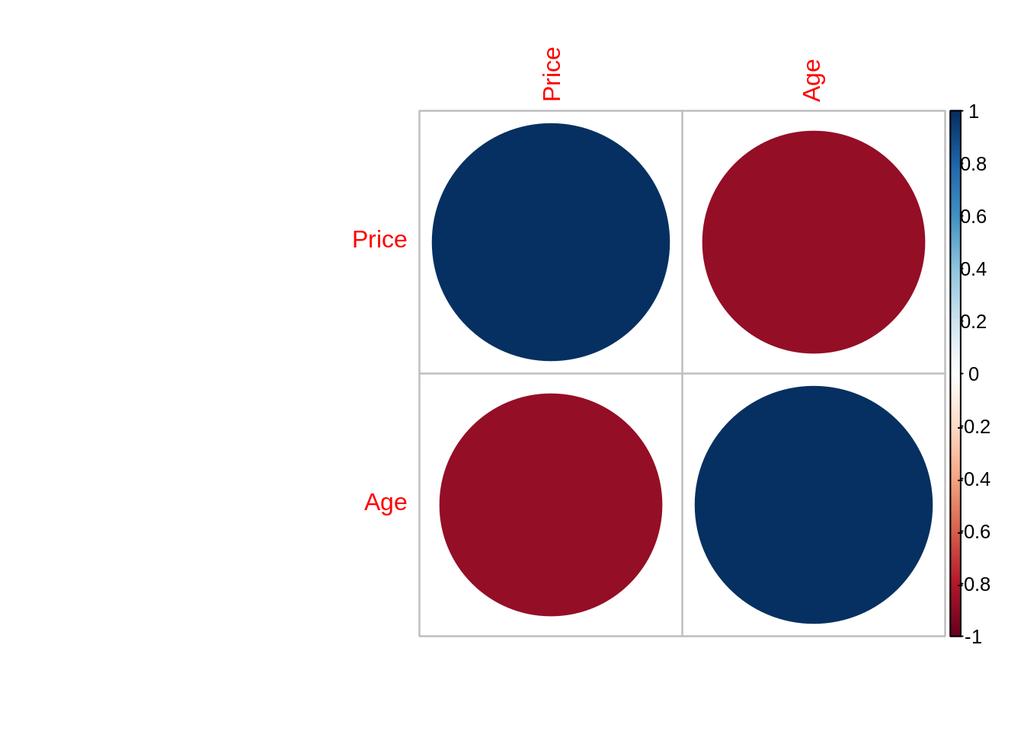

```r
library(corrplot)
corrplot(cor_data)
```

```r
#corrplot(cor_data, method = "number")
```

## Model Building

### Train Test Split (70:30) - Split the data into train and test datasets

```r
set.seed(123)
rows = seq(1, nrow(cars_data),1)
trainRows = sample(rows,(70*nrow(cars_data))/100)
cars_train = cars_data[trainRows,]
cars_test = cars_data[-trainRows,]
nrow(cars_train)
```

```
## [1] 1005
```

```r
nrow(cars_test)
```

```
## [1] 431
```

## Building the Linear Regression Model

- lm function is used to fit linear models

```r
LinReg = lm(Price ~ Age, data = cars_train)
coefficients(LinReg)
```

```
## (Intercept)         Age
##  26127.2684   -171.1292
```

- Summary displays the following:
  - Formula given (Call) - Shows the function call used to compute the regression model.
  - Residuals. Provide a quick view of the distribution of the residuals, which by definition have a mean zero.
  - Coefficients and the test statistic values. Shows the regression beta coefficients and their statistical significance. Predictor variables, that are significantly associated to the outcome variable, are marked by stars.
  - Residual Standard Error (RSE)
  - Multiple R- Squared (which we generally refer to as R squared or Co-efficient of Determination)
  - F statistic - Test for Model
- The statistical hypothesis is as follows :
  - Null Hypothesis (H0): the coefficients (slope) are equal to zero (i.e., no relationship between x and y)
  - Alternative Hypothesis (H1): the coefficients (slope) are not equal to zero (i.e., there is some relationship between x and y)

### Read the model summary

```r
## Summary of the linear model
summary(LinReg)
```

```
##
## Call:
## lm(formula = Price ~ Age, data = cars_train)
##
## Residuals:
##     Min      1Q  Median      3Q     Max
## -8429.2 -1001.0   -13.7   858.9 12875.6
##
## Coefficients:
##              Estimate Std. Error t value Pr(>|t|)
## (Intercept) 26127.268    275.810   94.73   <2e-16 ***
## Age          -171.129      2.987  -57.28   <2e-16 ***
## ---
## Signif. codes:  0 '***' 0.001 '**' 0.01 '*' 0.05 '.' 0.1 ' ' 1
##
## Residual standard error: 1757 on 1003 degrees of freedom
## Multiple R-squared:  0.7659, Adjusted R-squared:  0.7657
## F-statistic:  3282 on 1 and 1003 DF,  p-value: < 2.2e-16
```

- Try answering these questions (Interpreting model output) -
  1. Is the Slope significant?
  2. Is the Model significant?
  3. What is the predictive power of the model (R-squared)?
- In our example, both the p-values for the intercept and the predictor variable are highly significant, so we can reject the null hypothesis and accept the alternative hypothesis, which means that there is a significant association between the predictor and the outcome variables.

### Plot the data points and the line of best fit

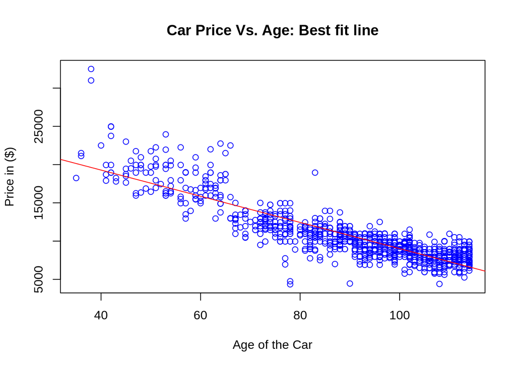

```r
plot(cars_train$Age,cars_train$Price,xlab="Age of the Car",ylab="Price in ($)",main="Car Price Vs. Age: Best fit line", col= "blue")
abline(LinReg,col="red",lwd=1)       # The function adds straight line to a plot
```

## Optional for info :

```r
#To extract the coefficients:

coefficients(LinReg)
```

```
## (Intercept)         Age
##  26127.2684   -171.1292
```

```r
coefficients(LinReg)[1]
```

```
## (Intercept)
##    26127.27
```

```r
coefficients(LinReg)[2]
```

```
##       Age
## -171.1292
```

## Extracting residuals and fitted values

```r
# To extract the residuals:
head(LinReg$residuals)
```

```
##        413       1132        587       1266       1347         66
## -3144.6723  2475.8166  -946.7678  1789.2043   475.8166  1090.4848
```

```r
# To extract the predictions
head(LinReg$fitted.values)
```

```
##       413      1132       587      1266      1347        66
## 12094.672  7474.183 10896.768  6960.796  7474.183 15859.515
```

## Residual Analysis

- In R four diagnostic plots can be obtained by calling the plot function on fitted model obtained using lm

### Validity of linear regression assumptions

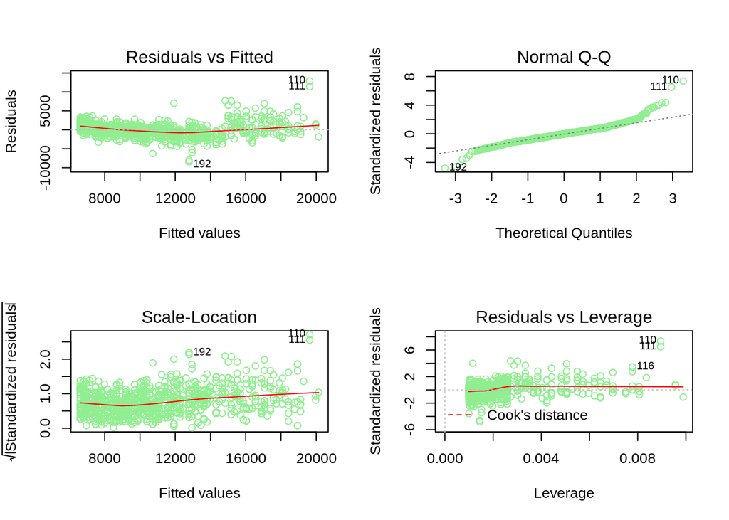

```r
par(mfrow = c(2,2))                         # par{graphics} helps us to Set the Graphical Parameters
plot(LinReg,lwd =1,col = 'light green')     # Check for validity of linear regression assumptions
```

### Plot residuals vs fitted values

- This will help us visualize how the residuals are distributed in relation to the fitted values

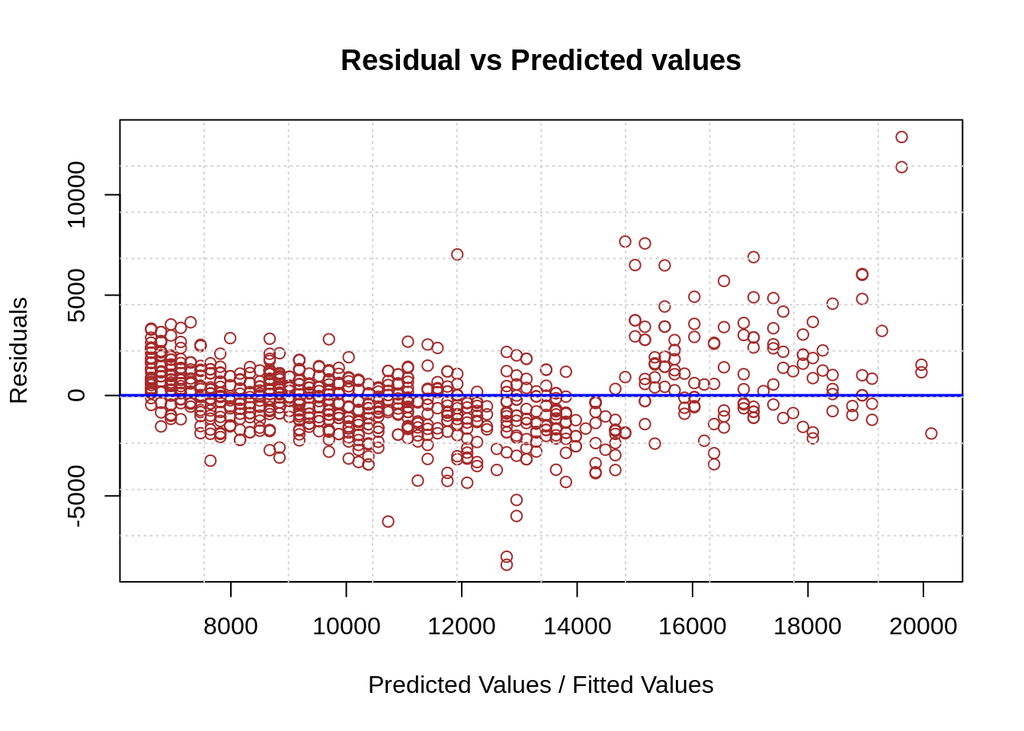

```r
plot(LinReg$fitted.values,LinReg$residuals,main = "Residual vs Predicted values", col = 'brown',lwd = 1,
xlab ="Predicted Values / Fitted Values", ylab = "Residuals")
abline(h = 0,col = 'blue',lwd=2)
grid(10,10,lwd=1)
```

## Predict on testdata

```r
test_prediction = predict(LinReg, cars_test)  # Fitted values
test_actual = cars_test$Price                 # Actual values
```

## Performance Metrics

Once we choose the model, we have to report performance metrics on the test data. We are going to report three error metrics for regression.

### Error Metrics for Regression

- Mean Absolute Error (MAE)

Create a function called mae that measures the mean absolute error, given the actual and predicted points.

$$MAE = \dfrac{1}{n}\times\sum_{i = 1}^{n}|y_{i} - \hat{y_{i}}|$$

```r
# We can create a function which would compute the error if we pass on two parameters to it.

mae <- function(actual, predicted){

  error <- actual - predicted

  mean(abs(error))

}
```

- Mean Squared Error (MSE)

Create a function called mse that measures the mean squared error, given the actual and predicted points.

$$MSE = \dfrac{1}{n}\times\sum_{i = 1}^{n}(y_{i} - \hat{y_{i}})^2$$

```r
mse <- function(actual, predicted){

  error <- actual - predicted

  mean(error^2)

}
```

- Root Mean Squared Error (RMSE)

Create a function called rmse that measures the root mean squared error, given the actual and predicted points.

$$RMSE = \sqrt{\dfrac{1}{n}\times\sum_{i = 1}^{n}(y_{i} - \hat{y_{i}})^2}$$

```r
rmse <- function(actual, predicted){

  error <- actual - predicted

  sqrt(mean(error^2))

}
```

### Report Performance Metrics

Report performance metrics obtained by using the chosen model on the test data.

```r
library(DMwR)
#Error verification on train data
regr.eval(cars_train$Price, LinReg$fitted.values)
```

```
##          mae          mse         rmse         mape
## 1.247148e+03 3.079272e+06 1.754786e+03 1.224397e-01
```

```r
#Error verification on test data
regr.eval(test_actual, test_prediction)
```

```
##          mae          mse         rmse         mape
## 1.247891e+03 2.963191e+06 1.721392e+03 1.184576e-01
```

## Confidence and Prediction Intervals

- Confidence Intervals talk about the average values intervals
- Prediction Intervals talk about the all individual values intervals

```r
Conf_Pred = data.frame(predict(LinReg, cars_test, interval="confidence",level=0.95))
Pred_Pred = data.frame(predict(LinReg, cars_test, interval="prediction",level=0.95))

names(Conf_Pred)
```

```
## [1] "fit" "lwr" "upr"
```

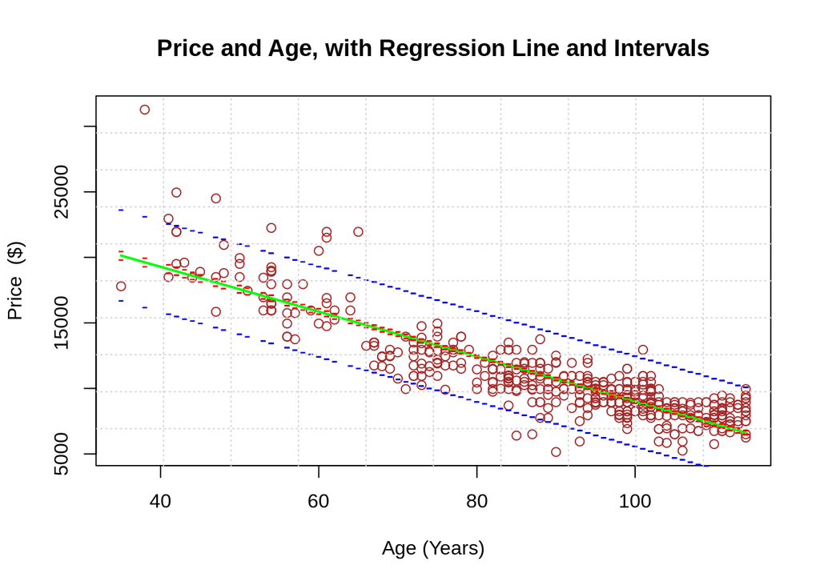

```r
plot(cars_test$Age, cars_test$Price,main = "Price and Age, with Regression Line and Intervals" ,xlab = "Age (Years)", ylab = "Price  ($)", col = 'brown')

points(cars_test$Age,Conf_Pred$fit,type="l", col="green", lwd=2)
points(cars_test$Age,Conf_Pred$lwr,pch="-", col="red", lwd=4)
points(cars_test$Age,Conf_Pred$upr,pch="-", col="red", lwd=4)
points(cars_test$Age,Pred_Pred$lwr,pch="-", col="blue", lwd=4)
points(cars_test$Age,Pred_Pred$upr,pch="-", col="blue", lwd=4)
grid(10,10,lwd =1)
```

- Confidence intervals tell you about how well you have determined the mean. Assume that the data really are randomly sampled from a Gaussian distribution. If you do this many times, and calculate a confidence interval of the mean from each sample, you’d expect about 95 % of those intervals to include the true value of the population mean. The key point is that the confidence interval tells you about the likely location of the true population parameter.
- Prediction intervals tell you where you can expect to see the next data point sampled. Assume that the data really are randomly sampled from a Gaussian distribution. Collect a sample of data and calculate a prediction interval. Then sample one more value from the population. If you do this many times, you’d expect that next value to lie within that prediction interval in 95% of the samples.The key point is that the prediction interval tells you about the distribution of values, not the uncertainty in determining the population mean